# Analyzing Sleep Data and Trends

Veronica Jenkins, Anika Deshpande, Katie Clayton

2022-12-13

## Introduction

The two data sets we have chosen to use are called “How Much Sleep Do Americans Really Get?” and “Sleep Data.” Both are from the website Kaggle. In this project, we renamed the first data set, TimeSleep while the second remained SleepQualityData. The TimeSleep data set was originally created to study the sleep patterns of people among different age groups. The attributes consist of year, period, average hours per day sleeping, standard error, type of days, age group, activity and sex. We chose not to use all the attributes, as they did not relate to our research questions. The attributes we did use throughout this project from this data set are Average Hours Per Day Sleeping, Type of Days, and Age Group. The SleepQuality data set was gathered from the Sleep Cycle iOS app between 2014-2018. The purpose of this gathered data was to compare the different ways people sleep, their length of sleep and how outside factors affected how much/how well they slept. There were multiple attributes included in this set, but we pulled a few we thought could contribute best to our project. The attributes we used are Hours of Sleep, Sleep Quality, and Movements Per Hour.

```r
#CamelCase
library(dplyr)
```

```r
library(ggplot2)
library(readxl)
library(tidyverse)
library(readr)
library(tidyr)
library(esquisse)

TimeSleep <- read_excel(
  path = "~/Desktop/TimeSleep.xlsx",
  skip = 1)

SleepQualityData <- read_excel("~/Desktop/SleepQualityData.xlsx", skip = 1)
```

```r
#rename columns
colnames(TimeSleep)<- c('Index','Year','Period','AverageHoursPerDaySleeping','Standard Error','Type of Days','AgeGroup','Activity','Sex')

#Make values in "Average Hours Per Day Sleeping" coloumns
# TimeSleep$`AverageHoursPerDaySleeping`<- as.numeric(TimeSleep$`AverageHoursPerDaySleeping`)
#
# #removes first column
# TimeSleep <- TimeSleep[-1,]
```

```r
#rename column names
colnames(SleepQualityData) <- c('Start', 'End', 'SleepQuality', 'Regularity', 'Mood', 'HeartRate(BPM)', 'Steps', 'AlarmMode', 'AirPressure(Pa)', 'City', 'MovementsPerHour', 'TimeInBed(Seconds)', 'TimeAsleep(Seconds)', 'TimeBeforeSleep(Seconds)', 'WindowStart', 'WindowStop', 'DidSnore', 'SnoreTime', 'WeatherTemperature(Celcius)', 'WeatherTypes', 'Notes')

#get rid of the first column
SleepQualityData <- SleepQualityData[-1,]

#creates new data frame of average hours of sleep
```

## Hours by Age

#### Is there change in mean hours of sleep per night depending on different age groups?

The Time Sleep data set presented two attributes that were easy to compare: Mean Hours of Sleep Per Night, and Age Group. We chose to incorporate this into our research because the phrase “I am so tired” is used very frequently among many different age groups. Additionally, different age groups are known to get more/less sleep than others, so we wanted to explore how much the difference is. After choosing the attributes, we made a table and were able to input the table into ggplot to create the bar graph.

```r
#creates new data frame with of average hour per day sleeping
HoursByAge<- TimeSleep%>%
  group_by(AgeGroup)%>%
  summarize(
    Mean=mean(AverageHoursPerDaySleeping)
  )
HoursByAge<-HoursByAge[-2,]
```

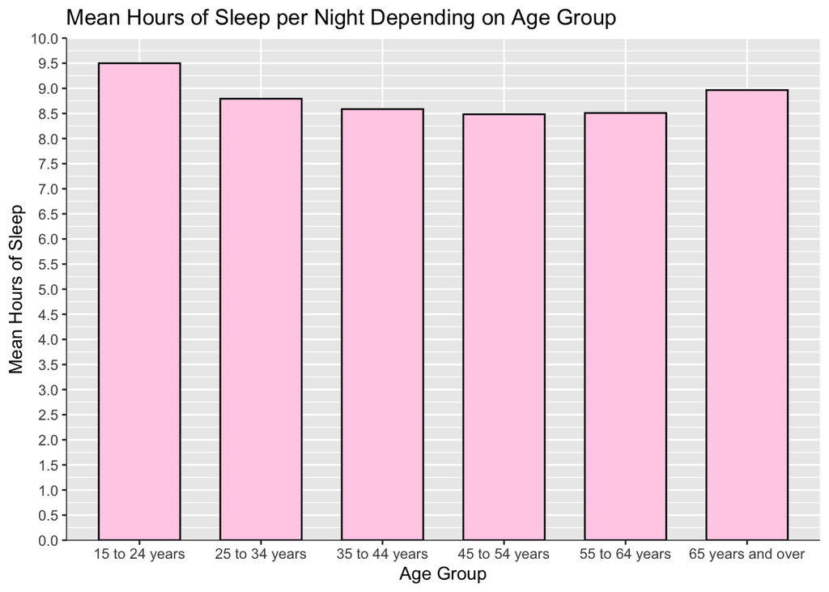

```r
# making the visualization for HoursByAge
#load ggplot, dplyr and HoursByAge data
library(scales)
library(ggplot2)
library(dplyr)

ggplot(
  data = HoursByAge,
  mapping = aes(x = AgeGroup, weight = Mean)
) +
  geom_bar(fill = "#FFD1E8", width = 0.67, color = "black") +
  # adding titles and labels
  labs(
    x = "Age Group",
    y = "Mean Hours of Sleep",
    title = "Mean Hours of Sleep per Night Depending on Age Group"
  ) +
  theme(axis.line.x = element_line(color="black", size = .25),
        axis.line.y = element_line(color="black", size = .25)
  ) +
  scale_y_continuous(breaks = seq(0,10, by = 0.5), limits = c(0,10), expand = c(0, 0))
```

## Sleep Quality by Hours of Sleep

#### How is sleep quality affected by hours of sleep per night?

For this question, we pulled data from the Sleep Quality Data set imported from excel. We selected the attributes Sleep Quality and Hours of Sleep. The attribute Sleep Quality is formatted as a percentage and is displayed in decimal format for the graph. Using the filtered data of the selected column, we displayed the data in a scatter plot with a line of best fit.

```r
#TidyData

#Create a dataframe with only the necessary columns
SleepQuality <- data.frame(SleepQualityData$'Start', SleepQualityData$'End', SleepQualityData$'SleepQuality')
#rename the columns


colnames(SleepQuality) <- c('Start', 'End', 'SleepQuality')

#Create a column calculating the difference in timestamps to get hours of sleep
SleepQuality <- transform(
  SleepQuality, HoursOfSleep= as.numeric(difftime(as.POSIXct(SleepQualityData$End), as.POSIXct(SleepQualityData$`Start`)), units = "hours"))

#round hours of sleep
SleepQuality$`HoursOfSleep` <- round(SleepQuality$`HoursOfSleep`, digits = 2)

#Convert sleep quality to numeric
SleepQualityData$`SleepQuality`<- as.numeric(SleepQualityData$`SleepQuality`)

#load a package to convert sleep quality to percent
library(scales)
library(formattable)
SleepQuality$`SleepQuality` <- formattable::percent(SleepQualityData$`SleepQuality`)

#Create a dataframe with the two neccessary columns and rename the columns
SleepQualityByHours<-data.frame(SleepQuality$`HoursOfSleep`, SleepQuality$`SleepQuality`)
colnames(SleepQualityByHours) <- c('HoursOfSleep', 'SleepQualityPercent')
```

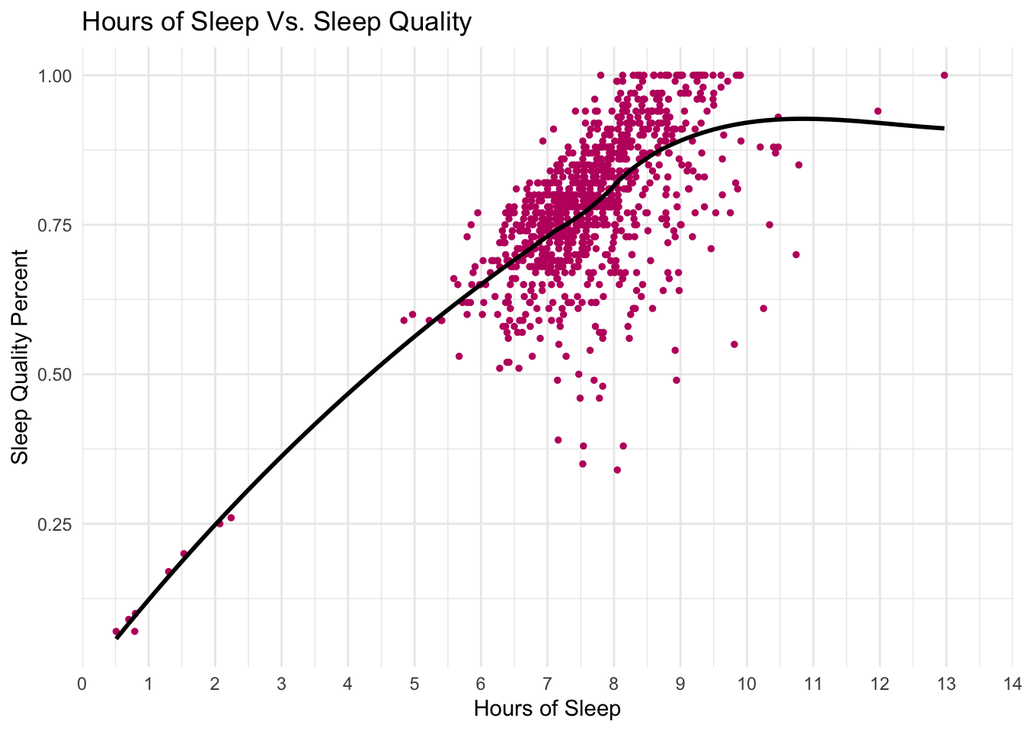

```r
#use ggplot to create a line graph using the data created
ggplot(
  data = SleepQualityByHours,
  mapping = aes(x = HoursOfSleep, y = SleepQualityPercent)
  ) +
  #customize point size, color, and shape
  geom_point(shape = "circle", size = 1.0, colour = "#BF1B6D") +
  #create a line of best fit and get rid of the spanning color
  geom_smooth(
    span = 0.75,
    se = FALSE,
    colour = "black",
    method = "loess",
    formula = y~x) +
  #create titles and axis labels
  labs(
    x = "Hours of Sleep",
    y = "Sleep Quality Percent",
    title = "Hours of Sleep Vs. Sleep Quality"
  ) +
  #set the graph appearance and fix scaling issues
  theme_minimal() +
  scale_x_continuous(breaks = seq(0,14, by = 1), limits = c(0,14), expand = c(0, 0))
```

## Hours of Sleep by Day Classification

#### How is the amount of sleep affected by what type of day it is?

For this research question, we pulled data from the TimeSleep data set. We wanted to compare statistical averages such as the min, 1st quartile, median, 3rd quartile, max, and outliers of hours of sleep per night grouped by what type of day it was. For example, a day classification would be non-holiday weekdays, weekend days and holidays, and all days (all types). Since weekends and holidays are presumed to be more relaxed for people, we thought it would be interesting to explore how much of a difference there actually is. This question will be explored through a box-plot and summary table to display the statistical averages mentioned.

#### Box-Plot Visualization

```r
#create an object for filtered data
HoursByDay <- TimeSleep %>%
  #organize all of the same day types together
  group_by(`Type of Days`) %>%
  #select the two columns needed: day type and average hours asleep
  select(`Type of Days`, `AverageHoursPerDaySleeping`)
```

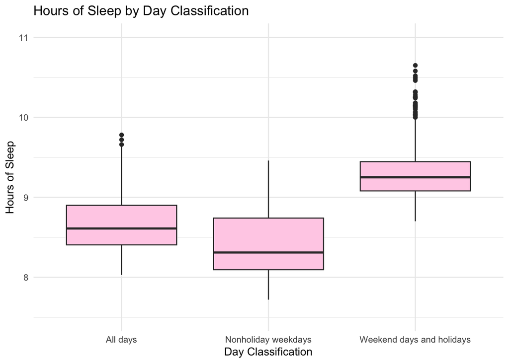

```r
#use ggplot to create a boxplot
ggplot(
  data = HoursByDay,
  mapping = aes(x = `Type of Days`, y = AverageHoursPerDaySleeping)
  ) +
  #assign a color to fill the box plot
  geom_boxplot(fill = "#FFD1E8") +
  #create titles and axis labels
  labs(
    x = "Day Classification",
    y = "Hours of Sleep",
    title = "Hours of Sleep by Day Classification"
  ) +
  #set graph appearance and fix axis scaling
  theme_minimal() +
  ylim(7.5, 11)
```

#### What is Shown?

As expected, the box-plot displays that Non-holiday weekdays have the lowest median hours of sleep and Weekend days and holidays having the highest median hours of sleep. There are no outliers in non-holiday weekdays showing consistent data within this category. There are however many outliers in the Weekend days and holidays group showing a higher number of hours of sleep. Going back to the proposed research question asking if people really get significantly more sleep on weekends and holidays or if it is just assumed, it is safe to conclude that the median is roughly one hour higher which is a relatively significant difference. In comparison, the overall (All days) median lies at roughly 8.6. These facts overall suggest weekend days and holidays do have a significant increase in amount of sleep, however the difference in sleep is not very large.

#### Summary Table

```r
library(readxl)
library(kableExtra)
library(janitor)
colnames(TimeSleep)<- c('Index','Year','Period','AverageHoursPerDaySleeping','Standard Error','Type of Days','Age Group','Activity','Sex')

TimeSleep <- TimeSleep[-1,]
DaysVsSleep <- TimeSleep %>%
  group_by(`Type of Days`) %>%
  select(`Type of Days`, `AverageHoursPerDaySleeping`) %>%
  summarize(
    across(
      .cols = where(is.numeric),
      .fns = list(
        min = ~min(`AverageHoursPerDaySleeping`, na.rm = TRUE),
        Q1 = ~quantile(`AverageHoursPerDaySleeping`, probs = 0.25, na.rm = TRUE),
        median = ~median(`AverageHoursPerDaySleeping`, na.rm = TRUE),
        Q3 = ~quantile(`AverageHoursPerDaySleeping`, probs = 0.75, na.rm = TRUE),
        max = ~max(`AverageHoursPerDaySleeping`, na.rm = TRUE),
        sam = ~mean(`AverageHoursPerDaySleeping`, na.rm = TRUE),
        sasd = ~sd(`AverageHoursPerDaySleeping`, na.rm = TRUE)
      ),
      #round the values to avoid unecessarily large amount of decimal spaces
      round(digits = 2)
    ),
    #get count and format it so that big numbers are separated with commas
    count = format(n(), big.mark = ","),
  )
#rename the columns
colnames(DaysVsSleep) <- c("Day Classification", "Min", "1st Quartile", "Median", "3rd Quartile", "Max", "Arithmetic Mean", "Arithmetic Standard Deviation", "Count")
#use kable to tidy the table (add caption, add grid, align columns)
DaysVsSleep %>%
  kable(
    caption = "Statistics on Average Hours Spent Sleeping and Type of Day",
    booktabs = TRUE,
    align = c("l", rep("c", 6))
  ) %>%
  #separate rows through striping the colors
  kableExtra::kable_styling(
    bootstrap_options = c("striped", "condensed"),
    font_size = 16
  ) %>%
  kableExtra::kable_classic()
```

Statistics on Average Hours Spent Sleeping and Type of Day

| Day Classification | Min | 1st Quartile | Median | 3rd Quartile | Max | Arithmetic Mean | Arithmetic Standard Deviation | Count |
| --- | --- | --- | --- | --- | --- | --- | --- | --- |
| All days | 8.03 | 8.4025 | 8.61 | 8.900 | 9.78 | 8.681783 | 0.3614004 | 314 |
| Nonholiday weekdays | 7.72 | 8.0950 | 8.31 | 8.740 | 9.46 | 8.404349 | 0.3925644 | 315 |
| Weekend days and holidays | 8.70 | 9.0800 | 9.25 | 9.445 | 10.65 | 9.334825 | 0.3881766 | 315 |

## Sleep Quality by Movements During Sleep

#### How do number of movements per hour affect sleep quality of an individual?

From the Sleep Quality data set, we proposed a question to see if there is any correlation between these two attributes. The two attributes used from the data set were `Sleep Quality` along the y axis and `Movements Per Hour` along the x axis. We also included a line of best fit after using ggplot to create a scatter plot showing correlation.

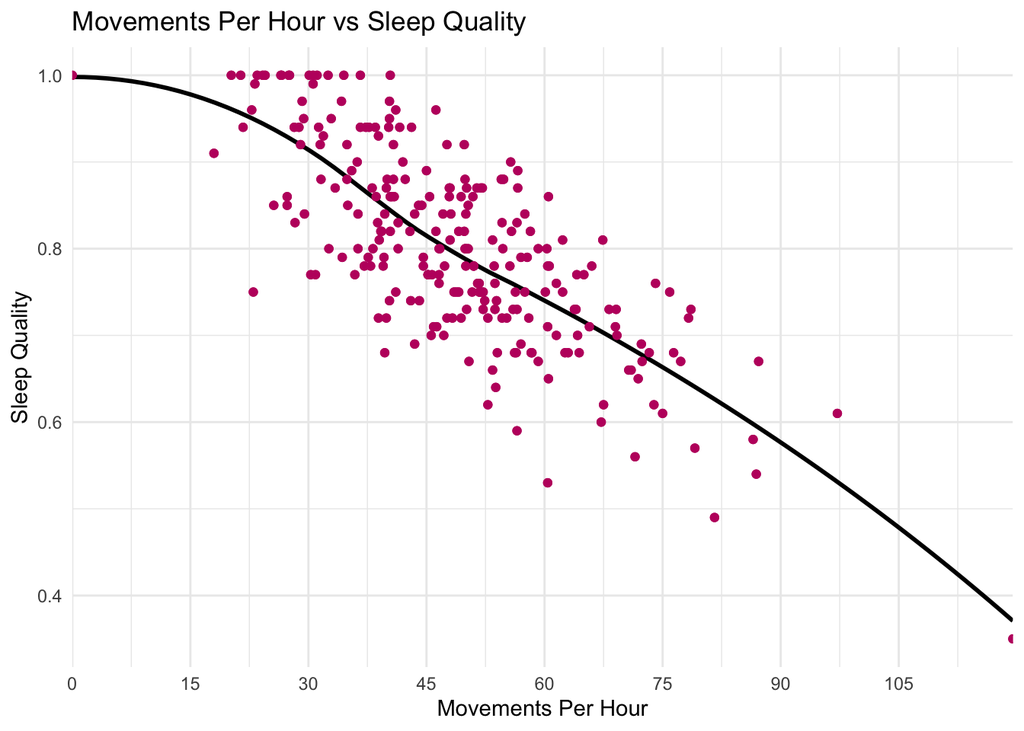

```r
#convert column data to numeric
SleepQualityData$`MovementsPerHour`<- as.numeric(SleepQualityData$`MovementsPerHour`)
SleepQualityData$`SleepQuality`<- as.numeric(SleepQualityData$`SleepQuality`)

#filter data
movementsVsTime <- SleepQualityData %>%
  select(MovementsPerHour, SleepQuality)

#subset data
movementsVsTime <- movementsVsTime[0:250, ]

#use ggplot to create a line graph. Select the data and x&y axis
ggplot(
  data = movementsVsTime,
  mapping = aes(x = MovementsPerHour, y = SleepQuality )
  ) +
  geom_point(shape = "circle", colour = "#BF1B6D") + #assign the points a shape and color and add a line of best fit
  geom_smooth(
    span = 0.75,
    se = FALSE,
    colour = "black",
    method = "loess",
    formula = y ~ x
  ) +
  geom_point(shape = "circle", colour = "#BF1B6D") +
  # adding titles and labels
  labs( # adding titles and labels
    x = "Movements Per Hour",
    y = "Sleep Quality",
    title = "Movements Per Hour vs Sleep Quality"
  ) +
  theme_minimal() + #set the graph appearance
  scale_x_continuous(breaks = seq(0,150, by = 15), expand = c(0, 0))  #fix the x axis scaling
```

## Conclusion

From our two data sets were able to gain a lot of insight about various factors that impact sleep. We were able to assess the amount of sleep that various age groups get each night. Our data also highlighted the positive relationship between the number of hours of sleep and sleep quality. This indicated that people of all age groups could benefit from sleeping more. Another characteristic impacting sleep quality was number of movements per hour. Our data showed a negative correlation between movements per hour and sleep quality indicating that more movement leads to lower quality sleep. We also found that typically people are getting more sleep on weekends and holidays than they are on a normal weekday. These visualizations could be used to help develop better ways to achieve quality sleep.